# Examining Colinearity and Distriubtion of Vegetation Covariates for Habitat Chapter

Anna Kurtin

7/18/2024

Before putting these habitat covariates into a model, I want to know whether any covariates are colinear and whether or not including nonrandom points is introducing bias into our datasets.

As a reminder, here’s how we’re defining variables within our data:

**Canopy vs. Subcanopy:** When deriving percent cover, I defined subcanopy as all vegetation >=.25m and <= 6m.; canopy as all vegetation >6m. When deriving vegetation height and standard deviation, I made a mistake and defined canopy as anything >= 6m and subcanopy anything >.25m and <6m. However, the data had 5-6 decimal places, so the number of pixels that actually fell exactly on that threshole that would have been changed is very small, so I don’t anticipate this will affect my analysis at all.

**Spatial Scales:** Landscape scale (`landsc`) indicates all vegetation within an 1000m radius of the point, Core (`core`) indicates all vegetation within 130m of the point, and point indicates vegetation at the veg survey point.

**LiDAR Metrics:** I looked at percent cover (`pct`), average height (`ht`) and standard deviation (`sd`) for the LiDAR metrics.

**Sampling Design:** We had points that were selected based on where surveyors thought was high-quality cuckoo habitat or places with past cuckoo observations (`nonrand`), points selected via GRTS sampling for the UMBEL Missouri and Madisor River monitoring projects (`grts`), and points selected via GRTS to investigate habitat use (`grts`).

```r
# Read in the monitoring locations
points_forhabchap <- read.csv("C:/Users/annak/OneDrive/Documents/UM/Research/Coding_Workspace/Cuckoo-Research/Data/Monitoring_Points/2023_AllARUPoints_FromDeploymentData.csv")
points_forhabchap <- points_forhabchap %>% create_site_col()
points_forhabchap <- points_forhabchap %>% group_by(site_id) %>% summarize(x = mean(x), y = mean(y))

# Read in the covariates derived from lidar data
lidar <- read.csv("C:/Users/annak/OneDrive/Documents/UM/Research/Coding_Workspace/Cuckoo-Research/Data/Vegetation_Data/Outputs/AllPoints_AllScales_LiDARMetrics_7-17-24.csv")
lidar <- lidar %>% separate(alt_point_id, into = c('point_id','year'), sep = "_", remove = FALSE)
lidar <- lidar %>% create_site_col()
lidar <- lidar %>% create_samp_col()
# group the data into grts points (either the points I selected for habitat use or the points selected via GRTS for the UMBEL monitoring) or nonrandomly selected points
lidar <- lidar %>% mutate(grts_grouped = case_when(sampling_design == "nonrand" ~ "nonrand",
                                               sampling_design == "mmr_grts"~ "grts",
                                               sampling_design == "habitat_grts" ~ "grts"))
# Filter out only the points usedin 2023, which are the only points I'm looking at for this chapter
lidar_23 <- lidar %>% filter(year == "23")
# some sites had three points, so let's take the average of the lidar metrics across those three to have one measurement per site
lidar_23 <- lidar_23 %>% group_by(site_id) %>% summarize(pct_can_landsc = round(mean(percent_canopy_landsc),2),
                                                   pct_subcan_landsc = round(mean(percent_subcan_landsc),2),
                                                   pct_can_core = round(mean(percent_canopy_core),2),
                                                   pct_subcan_core = round(mean(percent_subcan_core),2),
                                                   ht_can_core = round(mean(canopy_avgheight_core),2),
                                                   ht_subcan_core = round(mean(subcan_avgheight_core),2),
                                                   sd_subcan_core = round(mean(subcan_stdev_core),2),
                                                   grts_grouped = first(grts_grouped))

# Read in data on dominant shrub community
shrubs <- read.csv("C:/Users/annak/OneDrive/Documents/UM/Research/Coding_Workspace/Cuckoo-Research/Data/Habitat_Model_Covariates/Occupancy_Covariates/2023_ARUSites_ShrubDominantCommunity_6-19.csv")# %>% mutate(year = "23")
shrubs <- shrubs %>% select(site_id, dominant_community)
# read in data on tree species richness
tree_rich <- read.csv("C:/Users/annak/OneDrive/Documents/UM/Research/Coding_Workspace/Cuckoo-Research/Data/Habitat_Model_Covariates/Occupancy_Covariates/2023_ARUSites_TreeSppRich_6-19.csv")# %>% mutate(year = "23")
tree_rich <- tree_rich %>% select(site_id, spp_richness)
# Combine these into one dataframe and select columns of interest
all_dat <- left_join(points_forhabchap,lidar_23, by = "site_id")
all_dat <- left_join(all_dat, shrubs, by ="site_id")
all_dat <- left_join(all_dat, tree_rich, by = "site_id")
all_dat <- all_dat %>% select(site_id,
                           grts_grouped,
                           x,
                           y,
                           dominant_community,
                           spp_richness,
                           pct_can_landsc,
                           pct_subcan_landsc,
                           pct_can_core,
                           pct_subcan_core,
                           ht_can_core,
                           ht_subcan_core,
                           sd_subcan_core)
```

## Covariance matrix

First, let’s look at covariance. This plot shows the bivariate relationship between each set of data. The bottom half of the graph shows the correlation coefficient between the two variables, with red indicating a negative relationship and blue indicating a positive relationship. The top half of the graph mirrors the same combinations, showing the relationship as a scatterplot.

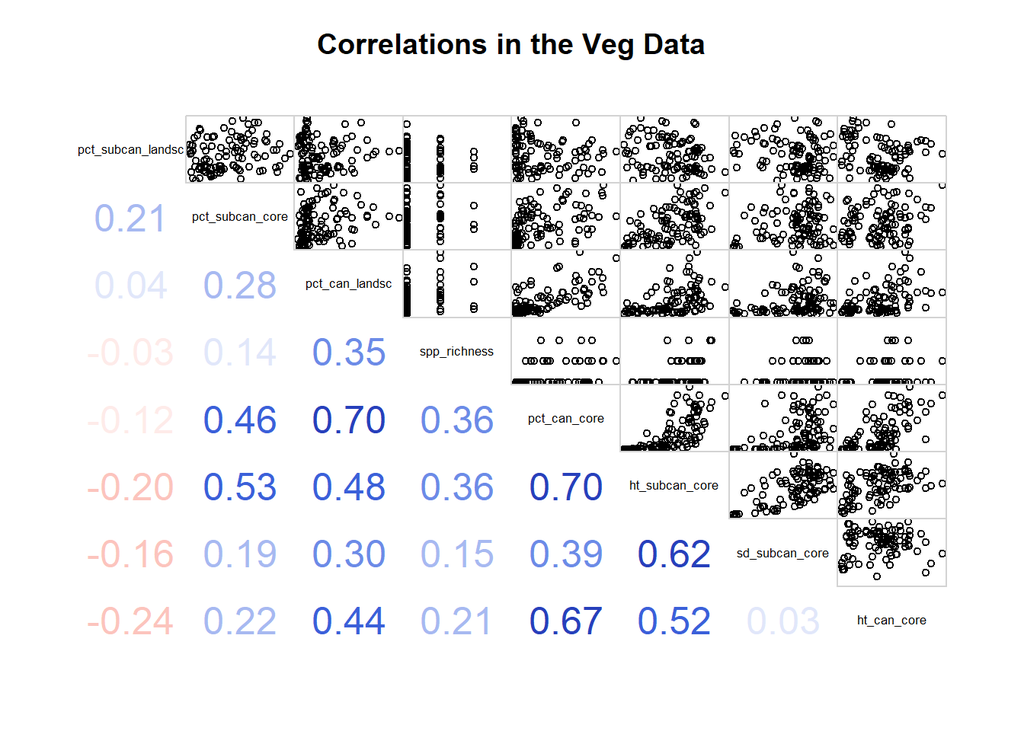

```r
corrgram(all_dat[6:13], order=TRUE, lower.panel=panel.cor,
         upper.panel=panel.pts, text.panel=panel.txt,
         main="Correlations in the Veg Data")
```

It doesn’t look like there is severe correlation in this dataset, but I’ve split out the most correlated variables based on the natural breaks in the data.

R > .6:

- percent canopy landscape ~ percent canopy core (R=.70)
- percent canopy core and subcanopy height core (R=.70)
- percent canopy core ~ canopy height core (R=.67)
- subcanopy height core ~ subcanopy standard deviation (R=.62)

### Should we combine some of these covariates to reduce the number of parameters in our model while still answering our research question? If so, what is the best way to go about this?

## Distribution of points - boxplots and histograms

### Landscape Scale

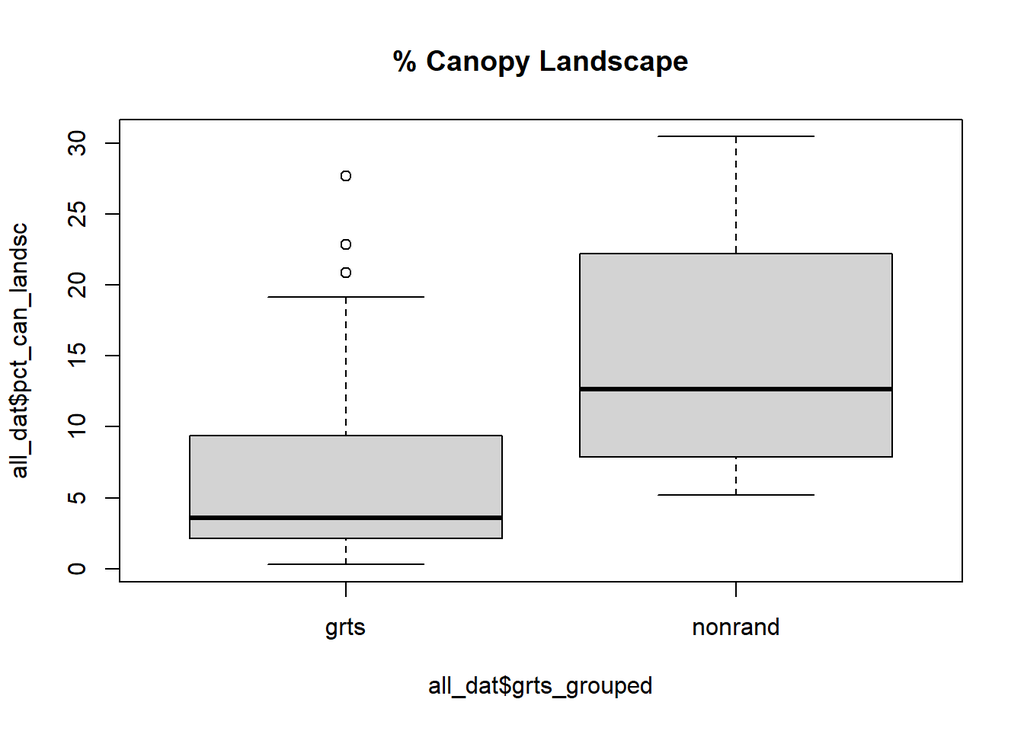

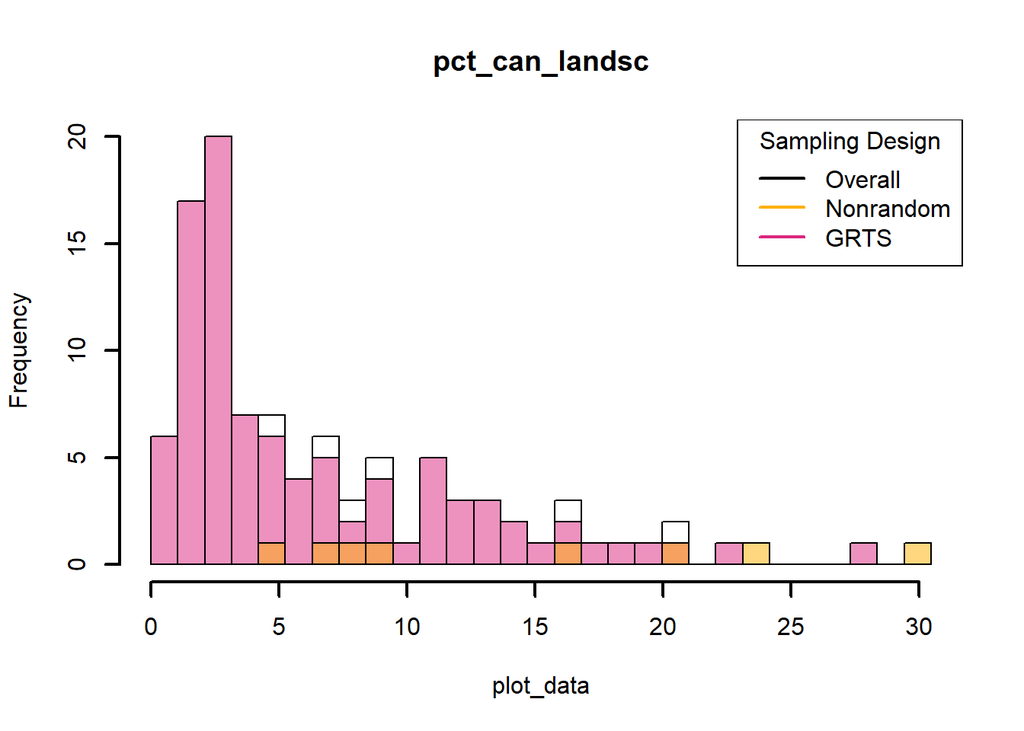

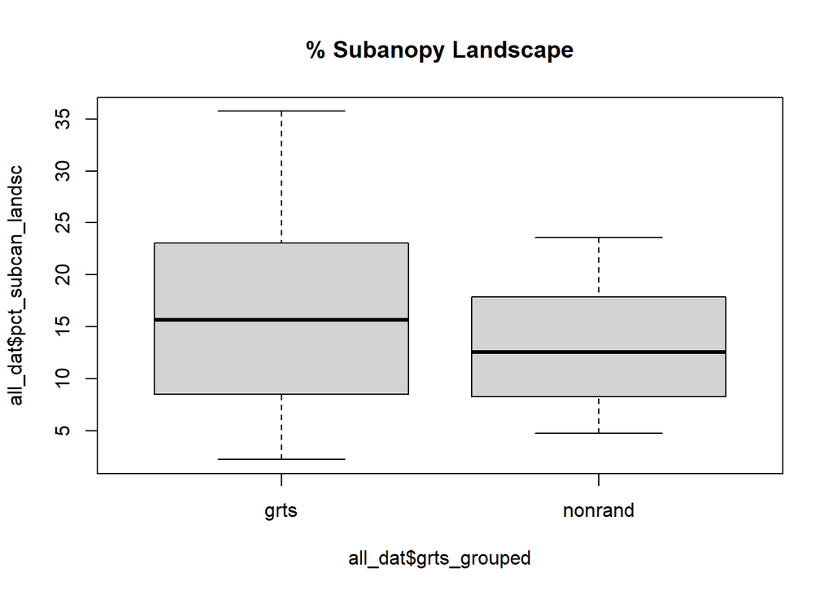

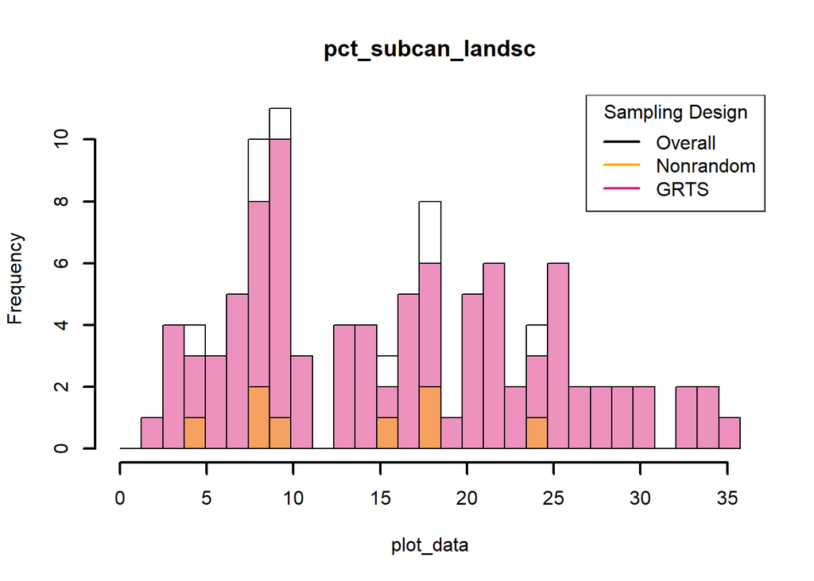

### Core Area

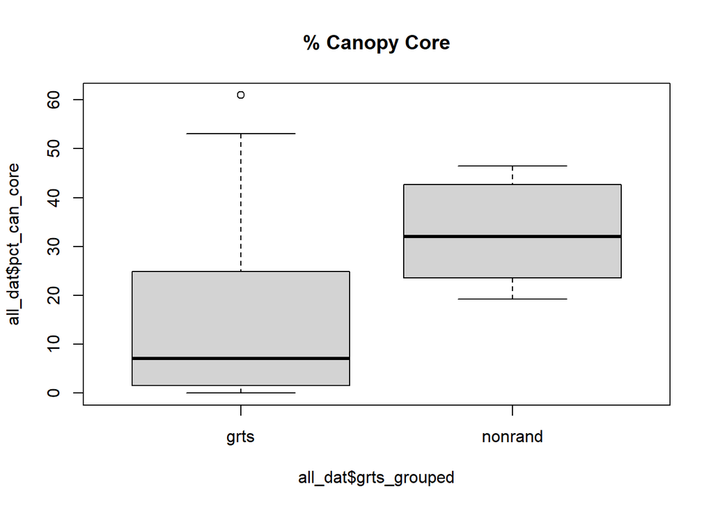

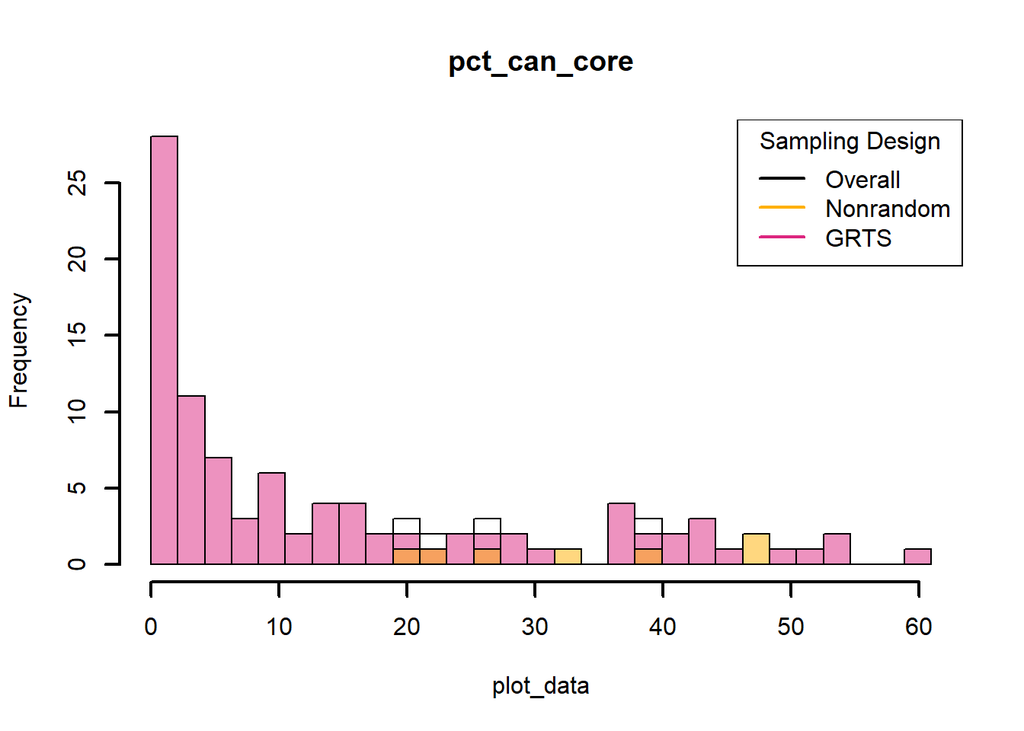

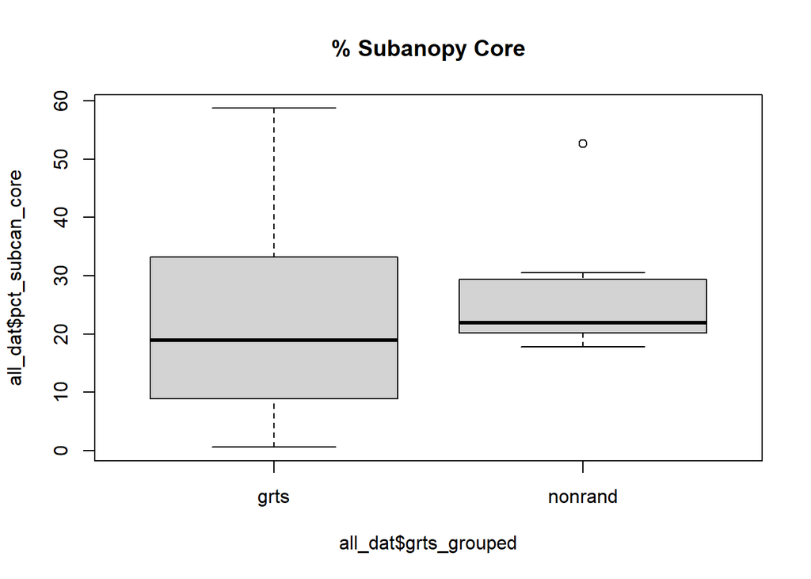

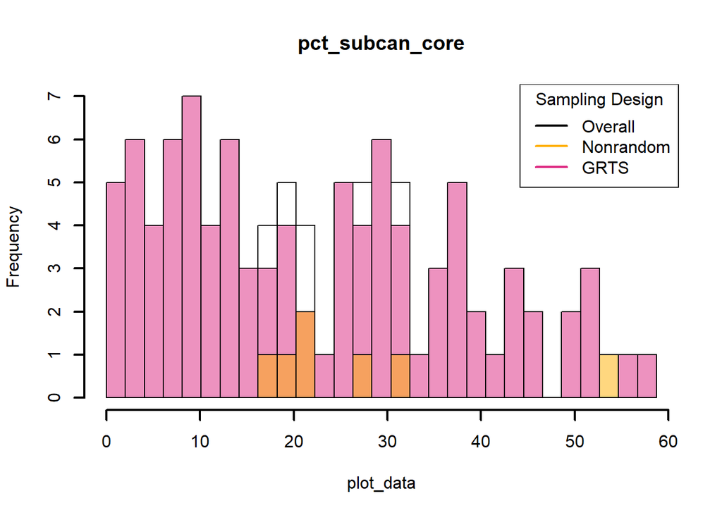

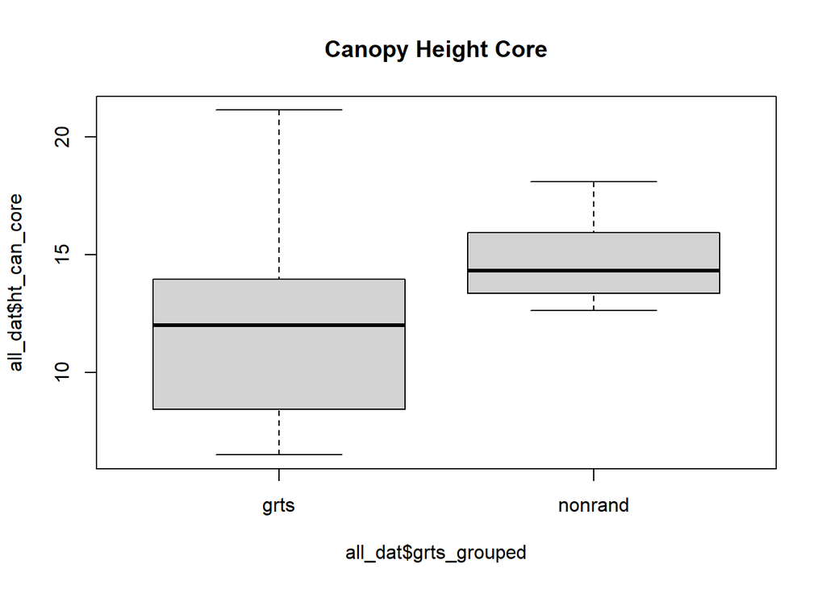

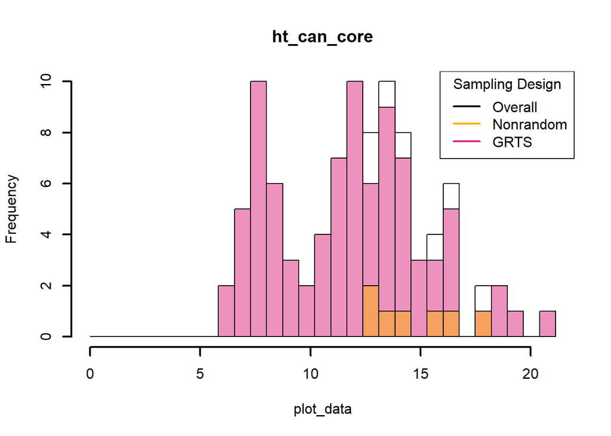

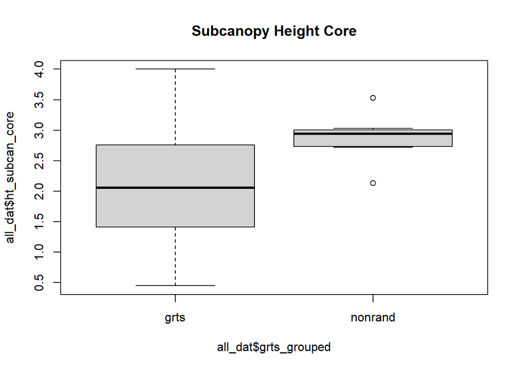

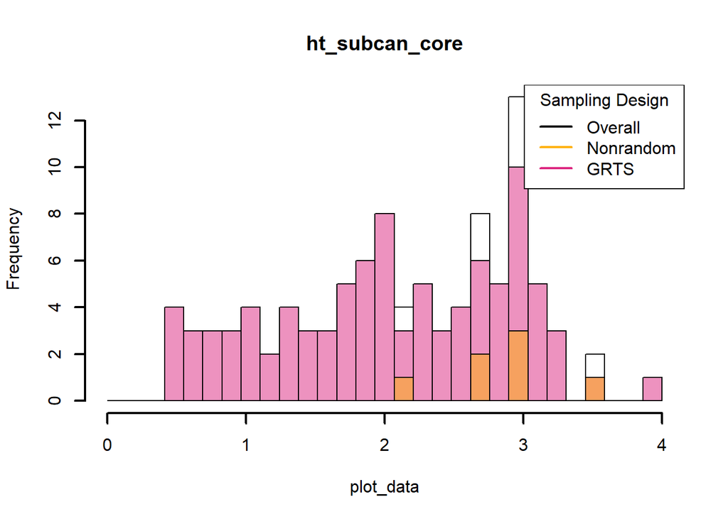

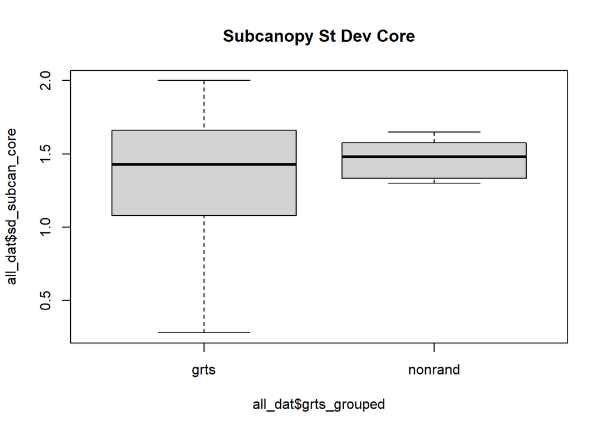

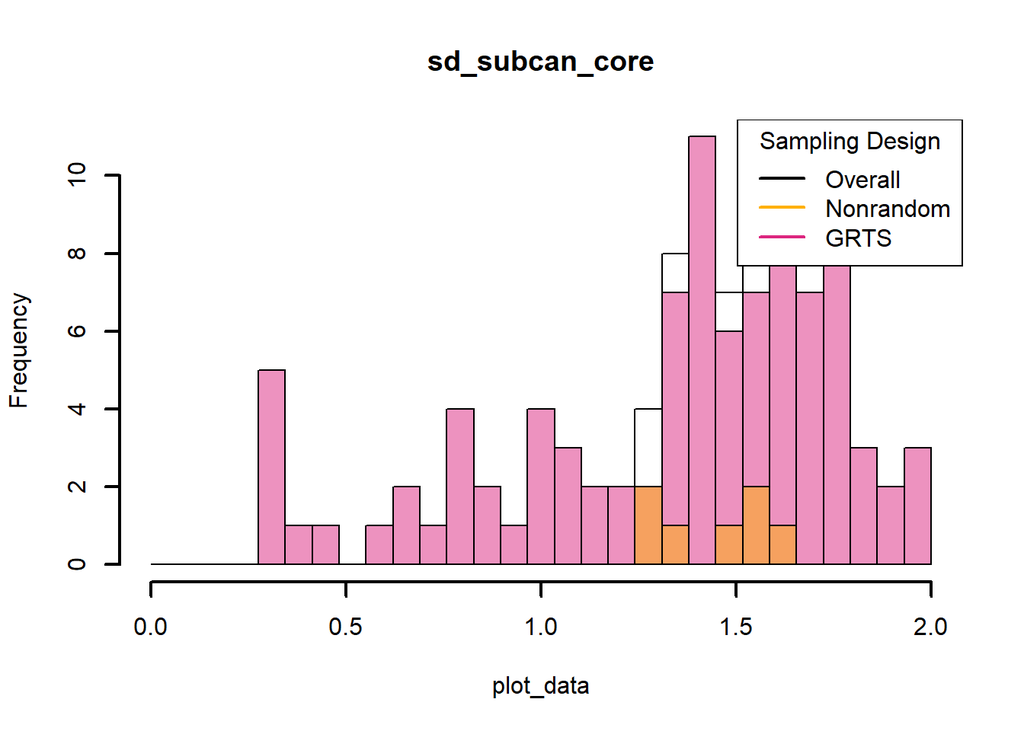

## Point Level

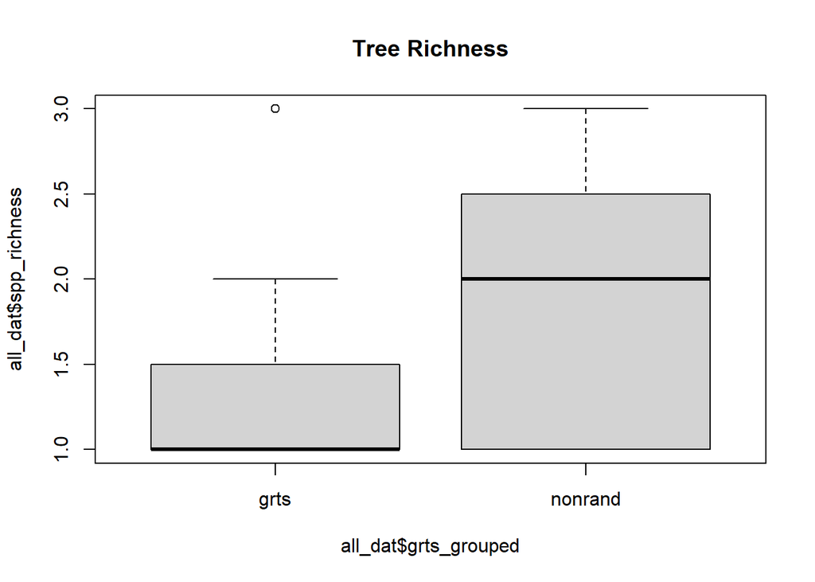

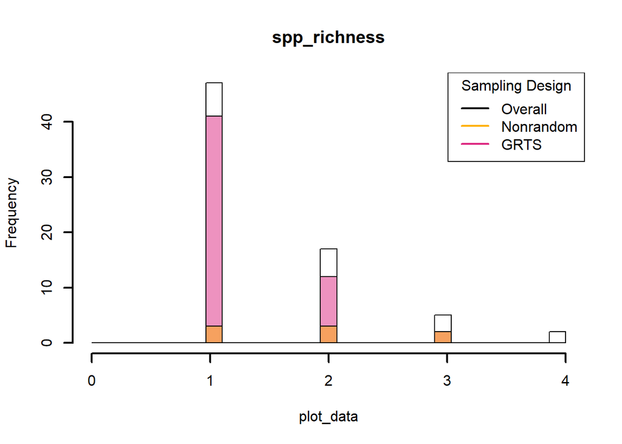

### It looks like the nonrandom points have generally higher tree species richness, but this doesn’t strike me as a concern overall, as it introduces a wider range of this covariate that will make it easier to model.

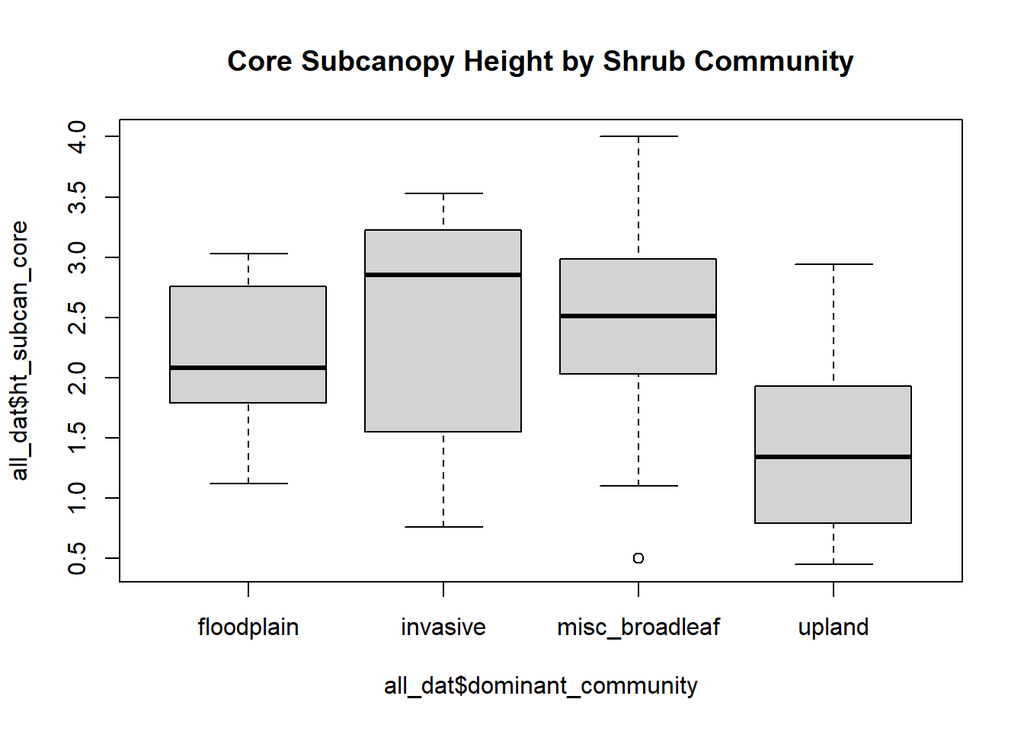

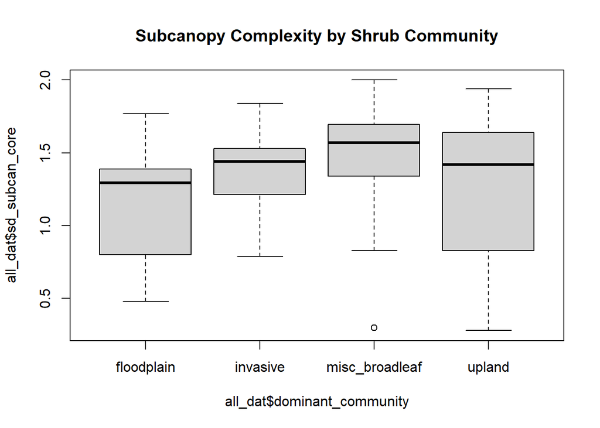

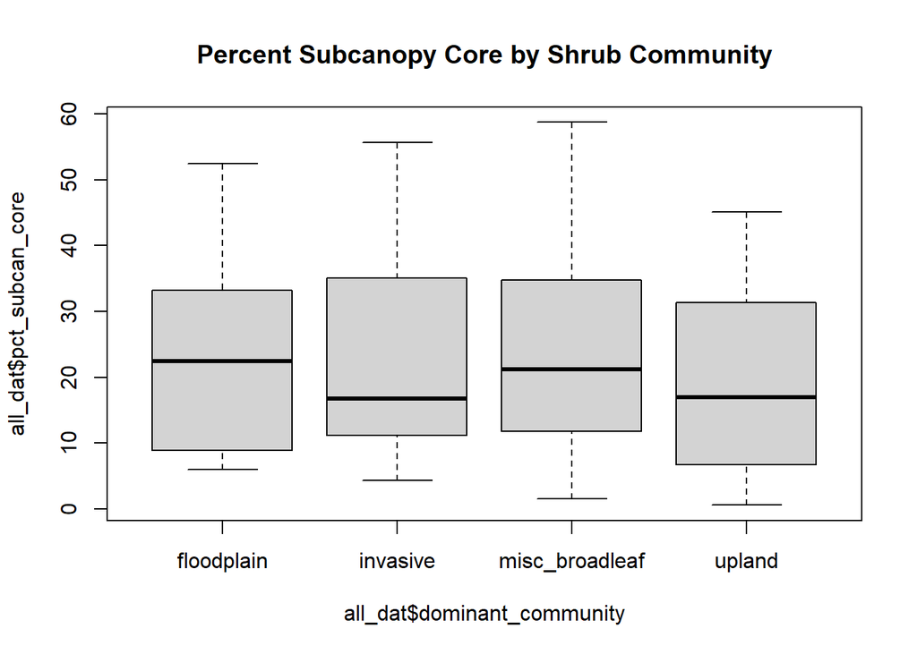

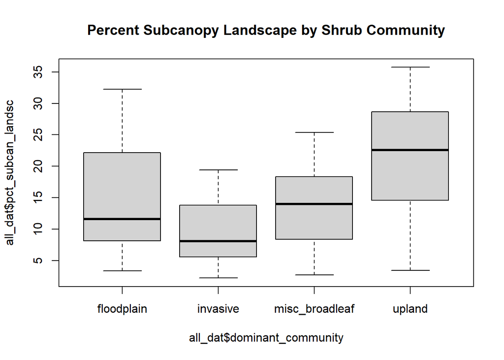

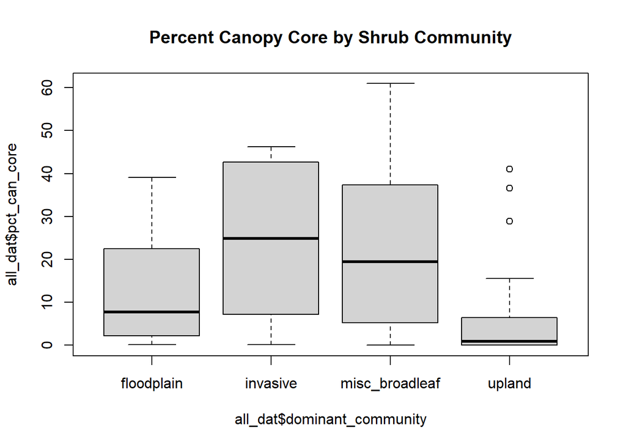

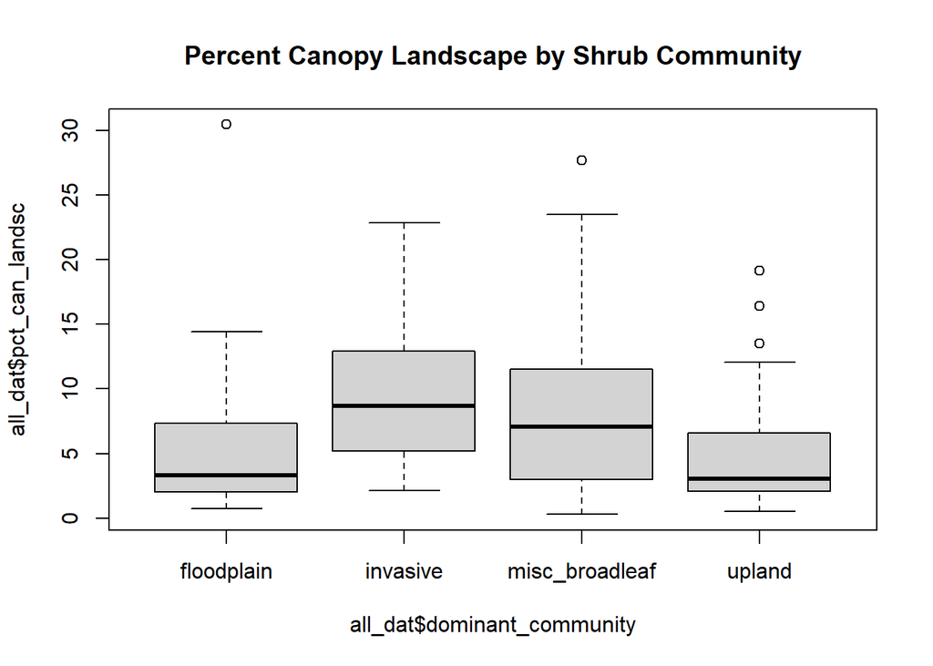

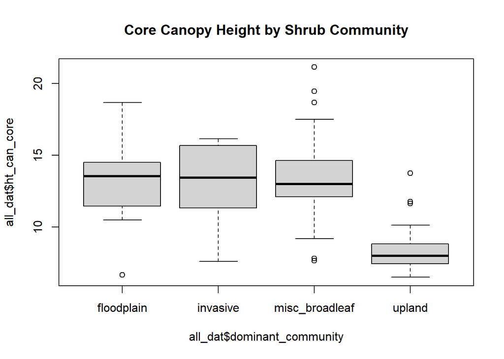

### None of these variables covary with dominant shrub community in unexpected ways. Are there any trends here that indicate colinearity that we should be concerned about? Is there a more robust way to test for this?